# Coursera Peer graded assignment 4

2023-06-07

# Coursera Practical Machine Learning Peer Assessment

## Background

Using devices such as Jawbone Up, Nike FuelBand, and Fitbit it is now possible to collect a large amount of data about personal activity relatively inexpensively. These type of devices are part of the quantified self movement – a group of enthusiasts who take measurements about themselves regularly to improve their health, to find patterns in their behavior, or because they are tech geeks. One thing that people regularly do is quantify how much of a particular activity they do, but they rarely quantify how well they do it. In this project, your goal will be to use data from accelerometers on the belt, forearm, arm, and dumbell of 6 participants. They were asked to perform barbell lifts correctly and incorrectly in 5 different ways. More information is available from the website here: http://web.archive.org/web/20161224072740/http:/groupware.les.inf.puc-rio.br/har (see the section on the Weight Lifting Exercise Dataset).

## Data Loading

```r
dfTrain <- read.csv("Input Data/pml-training.csv", stringsAsFactors = F,na.strings = c("","NA","#DIV/0!"))
dfTest <- read.csv("Input Data/pml-testing.csv", stringsAsFactors = F,na.strings = c("","NA","#DIV/0!"))
dim(dfTrain); dim(dfTest)
```

```
## [1] 19622   160
```

```
## [1]  20 160
```

## Data Exploration and Cleaning

```r
table(dfTrain$classe)
```

```
##
##    A    B    C    D    E
## 5580 3797 3422 3216 3607
```

Since we choose a random forest model and we have a data set with too many columns, first we check if we have many problems with columns without data. So, remove columns that have less than 60% of data entered.

```r
# Number of cols with less than 60% of data
sum((colSums(!is.na(dfTrain[,-ncol(dfTrain)])) < 0.6*nrow(dfTrain)))
```

[1] 100

```r
# apply our definition of remove columns that most doesn't have data, before its apply to the model.

Keep <- c((colSums(!is.na(dfTrain[,-ncol(dfTrain)])) >= 0.6*nrow(dfTrain)))
dfTrain   <-  dfTrain[,Keep]
```

## Data Sets Partitions Definitions

Create data partitions of training and validating data sets.

```r
set.seed(101)
inTrain = createDataPartition(dfTrain$classe, p=0.60, list=FALSE)
training = dfTrain[inTrain,]
validating = dfTrain[-inTrain,]

# number of rows and columns of data in the training set

dim(training)
```

```
## [1] 11776    60
```

```r
# number of rows and columns of data in the validating set

dim(validating)
```

```
## [1] 7846   60
```

# Data modeling

We will fit a model using **Random Forest** and **XGBoost** for several reasons:

1. With tree-based models, **you can safely ignore** predictors correlation issues
2. Zero- and Near Zero-Variance Predictors **does not** imply on tree-based models
3. As each feature is processed separately, and the possible splits of the data don’t depend on scaling, no preprocessing like normalization or standardization of features is needed for decision tree algorithms.

## Random forest

### Model

```r
controlRf <- trainControl(method="cv", 5, allowParallel = TRUE)
modelRf <- train(classe ~ ., data=training, method="rf", trControl=controlRf, ntree=250)
modelRf
```

```
## Random Forest
##
## 11776 samples
##    59 predictor
##     5 classes: 'A', 'B', 'C', 'D', 'E'
##
## No pre-processing
## Resampling: Cross-Validated (5 fold)
## Summary of sample sizes: 9420, 9422, 9420, 9422, 9420
## Resampling results across tuning parameters:
##
##   mtry  Accuracy   Kappa
##    2    0.9942258  0.9926958
##   41    0.9999151  0.9998926
##   81    0.9997453  0.9996778
##
## Accuracy was used to select the optimal model using the largest value.
## The final value used for the model was mtry = 41.
```

## XGBoost

```r
controlXGB <- trainControl(method="cv", 5, allowParallel = TRUE)
modelXGB <- train(classe ~ ., data=training, method="xgbTree", trControl=controlXGB)
```

[output not shown]

[output cut: 305 more lines]

[output not shown]

```r
modelXGB
```

```
## eXtreme Gradient Boosting
##
## 11776 samples
##    59 predictor
##     5 classes: 'A', 'B', 'C', 'D', 'E'
##
## No pre-processing
## Resampling: Cross-Validated (5 fold)
## Summary of sample sizes: 9421, 9421, 9421, 9421, 9420
## Resampling results across tuning parameters:
##
##   eta  max_depth  colsample_bytree  subsample  nrounds  Accuracy   Kappa
##   0.3  1          0.6               0.50        50      0.9997452  0.9996778
##   0.3  1          0.6               0.50       100      0.9996603  0.9995704
##   0.3  1          0.6               0.50       150      0.9996603  0.9995704
##   0.3  1          0.6               0.75        50      0.9995754  0.9994629
##   0.3  1          0.6               0.75       100      0.9995754  0.9994629
##   0.3  1          0.6               0.75       150      0.9995754  0.9994629
##   0.3  1          0.6               1.00        50      0.9995754  0.9994629
##   0.3  1          0.6               1.00       100      0.9995754  0.9994629
##   0.3  1          0.6               1.00       150      0.9995754  0.9994629
##   0.3  1          0.8               0.50        50      0.9996603  0.9995704
##   0.3  1          0.8               0.50       100      0.9996603  0.9995704
##   0.3  1          0.8               0.50       150      0.9996603  0.9995704
##   0.3  1          0.8               0.75        50      0.9995754  0.9994629
##   0.3  1          0.8               0.75       100      0.9995754  0.9994629
##   0.3  1          0.8               0.75       150      0.9995754  0.9994629
##   0.3  1          0.8               1.00        50      0.9995754  0.9994629
##   0.3  1          0.8               1.00       100      0.9995754  0.9994629
##   0.3  1          0.8               1.00       150      0.9995754  0.9994629
##   0.3  2          0.6               0.50        50      0.9996603  0.9995704
##   0.3  2          0.6               0.50       100      0.9996603  0.9995704
##   0.3  2          0.6               0.50       150      0.9996603  0.9995704
##   0.3  2          0.6               0.75        50      0.9995754  0.9994629
##   0.3  2          0.6               0.75       100      0.9995754  0.9994629
##   0.3  2          0.6               0.75       150      0.9995754  0.9994629
##   0.3  2          0.6               1.00        50      0.9995754  0.9994629
##   0.3  2          0.6               1.00       100      0.9995754  0.9994629
##   0.3  2          0.6               1.00       150      0.9995754  0.9994629
##   0.3  2          0.8               0.50        50      0.9997452  0.9996778
```

[output cut: 73 more lines]

```
##   0.4  3          0.8               0.50       150      0.9996603  0.9995703
##   0.4  3          0.8               0.75        50      0.9995754  0.9994629
##   0.4  3          0.8               0.75       100      0.9995754  0.9994629
##   0.4  3          0.8               0.75       150      0.9995754  0.9994629
##   0.4  3          0.8               1.00        50      0.9995754  0.9994629
##   0.4  3          0.8               1.00       100      0.9995754  0.9994629
##   0.4  3          0.8               1.00       150      0.9995754  0.9994629
##
## Tuning parameter 'gamma' was held constant at a value of 0
## Tuning
##  parameter 'min_child_weight' was held constant at a value of 1
## Accuracy was used to select the optimal model using the largest value.
## The final values used for the model were nrounds = 50, max_depth = 1, eta
##  = 0.4, gamma = 0, colsample_bytree = 0.6, min_child_weight = 1 and subsample
##  = 0.5.
```

### Performance of the model on the validation data set

```r
predict_XGB <- predict(modelXGB, validating)
confusionMatrix(as.factor(validating$classe), predict_XGB)
```

```
## Confusion Matrix and Statistics
##
##           Reference
## Prediction    A    B    C    D    E
##          A 2232    0    0    0    0
##          B    0 1518    0    0    0
##          C    0    0 1368    0    0
##          D    0    0    0 1284    2
##          E    0    0    0    0 1442
##
## Overall Statistics
##
##                Accuracy : 0.9997
##                  95% CI : (0.9991, 1)
##     No Information Rate : 0.2845
##     P-Value [Acc > NIR] : < 2.2e-16
##
##                   Kappa : 0.9997
##
##  Mcnemar's Test P-Value : NA
##
## Statistics by Class:
##
##                      Class: A Class: B Class: C Class: D Class: E
## Sensitivity            1.0000   1.0000   1.0000   1.0000   0.9986
## Specificity            1.0000   1.0000   1.0000   0.9997   1.0000
## Pos Pred Value         1.0000   1.0000   1.0000   0.9984   1.0000
## Neg Pred Value         1.0000   1.0000   1.0000   1.0000   0.9997
## Prevalence             0.2845   0.1935   0.1744   0.1637   0.1840
## Detection Rate         0.2845   0.1935   0.1744   0.1637   0.1838
## Detection Prevalence   0.2845   0.1935   0.1744   0.1639   0.1838
## Balanced Accuracy      1.0000   1.0000   1.0000   0.9998   0.9993
```

# Compare models

```r
# collect resamples
model_results <- resamples(list(RF=modelRf, XGB=modelXGB))
# summarize the distributions
summary(model_results)
```

```
##
## Call:
## summary.resamples(object = model_results)
##
## Models: RF, XGB
## Number of resamples: 5
##
## Accuracy
##          Min.   1st Qu. Median      Mean 3rd Qu. Max. NA's
## RF  0.9995756 1.0000000      1 0.9999151       1    1    0
## XGB 0.9995754 0.9995754      1 0.9998301       1    1    0
##
## Kappa
##          Min.  1st Qu. Median      Mean 3rd Qu. Max. NA's
## RF  0.9994631 1.000000      1 0.9998926       1    1    0
## XGB 0.9994629 0.999463      1 0.9997852       1    1    0
```

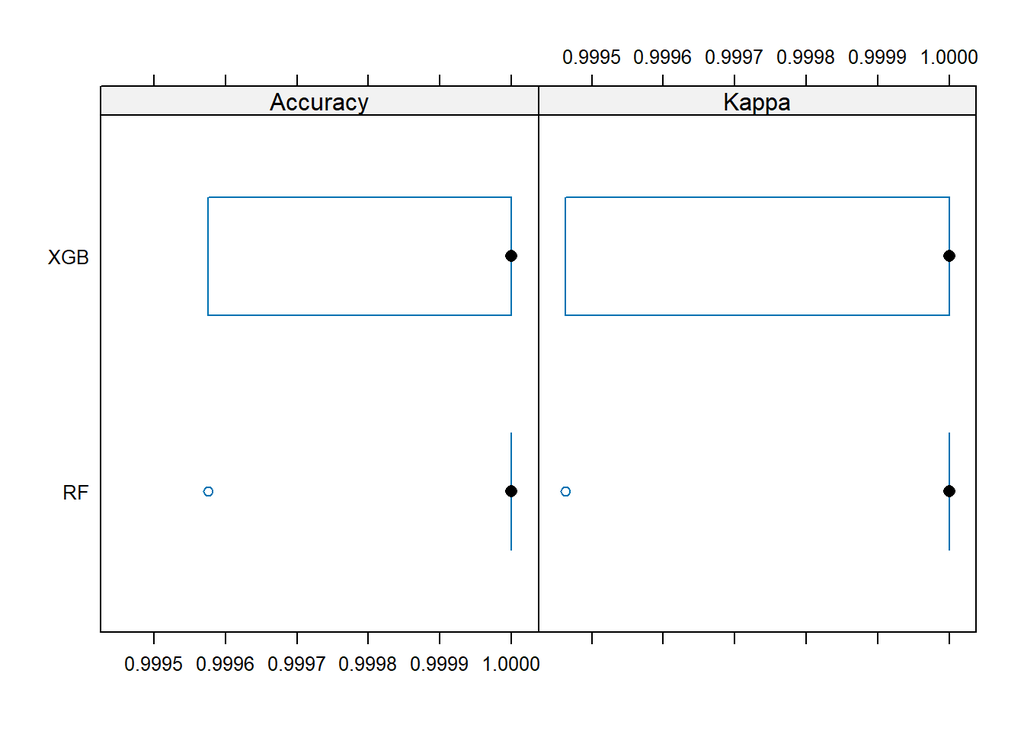

```r
# boxplots of results
bwplot(model_results)
```

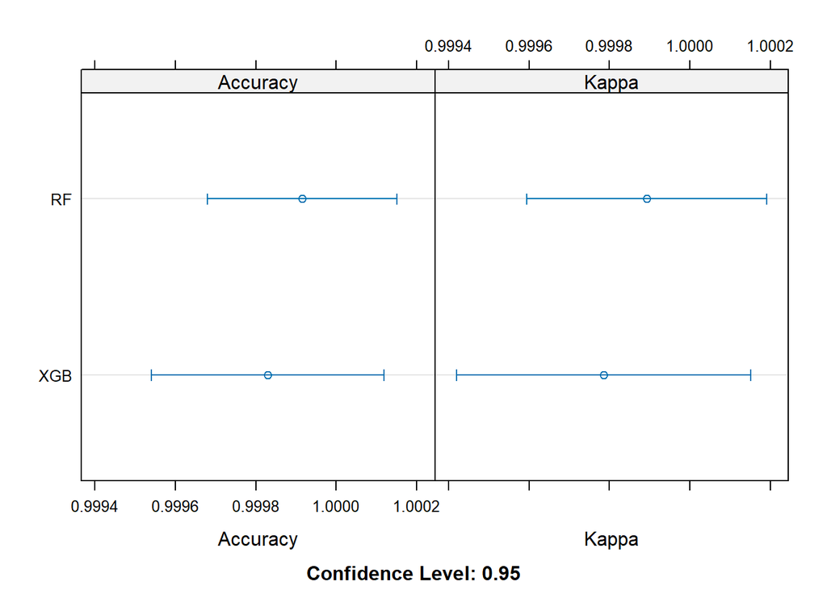

```r
# dot plots of results
dotplot(model_results)
```

# Predict Test data with RF and XGB

```r
resultRf <- predict(modelRf, dfTest[, -length(names(dfTest))])
resultXGB <- predict(modelXGB, dfTest[, -length(names(dfTest))])
resultRf
```

```
##  [1] A A A A A A A A A A A A A A A A A A A A
## Levels: A B C D E
```

```r
resultXGB
```

```
##  [1] A A A A A A A A A A A A A A A A A A A A
## Levels: A B C D E
```

```r
confusionMatrix(resultRf, resultXGB)
```

```
## Confusion Matrix and Statistics
##
##           Reference
## Prediction  A  B  C  D  E
##          A 20  0  0  0  0
##          B  0  0  0  0  0
##          C  0  0  0  0  0
##          D  0  0  0  0  0
##          E  0  0  0  0  0
##
## Overall Statistics
##
##                Accuracy : 1
##                  95% CI : (0.8316, 1)
##     No Information Rate : 1
##     P-Value [Acc > NIR] : 1
##
##                   Kappa : NaN
##
##  Mcnemar's Test P-Value : NA
##
## Statistics by Class:
##
##                      Class: A Class: B Class: C Class: D Class: E
## Sensitivity                 1       NA       NA       NA       NA
## Specificity                NA        1        1        1        1
## Pos Pred Value             NA       NA       NA       NA       NA
## Neg Pred Value             NA       NA       NA       NA       NA
## Prevalence                  1        0        0        0        0
## Detection Rate              1        0        0        0        0
## Detection Prevalence        1        0        0        0        0
## Balanced Accuracy          NA       NA       NA       NA       NA
```